# GO analyses for meox1 adjpval

### 1.8.3 ORA ( combined ): Enrichment map

Network graph connecting GO terms that share overlapping genes - clusters of connected terms suggest a shared underlying biological process rather than independent findings. **Expected:** tight clusters of related terms. **Unexpected:** many isolated, unconnected terms, suggesting the significant terms are thematically scattered rather than coherent.

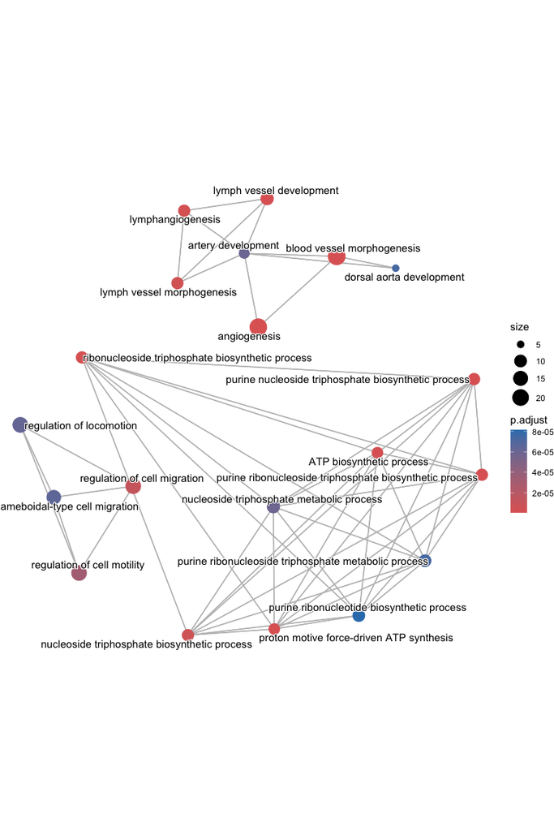

*PDF saved to:* `../output/figure_extended/go_adjpval//hmVEC__mVEC_ego_combined_emapplot.pdf`

### 1.8.4 ORA ( combined ): Category-gene network

Shows which specific genes drive which enriched terms, useful for tracing a term back to the actual DE genes behind it. **Expected:** recognisable marker genes linking to expected terms. **Unexpected:** a term driven entirely by one or two genes rather than a broad gene set - weaker evidence than a term supported by many genes.

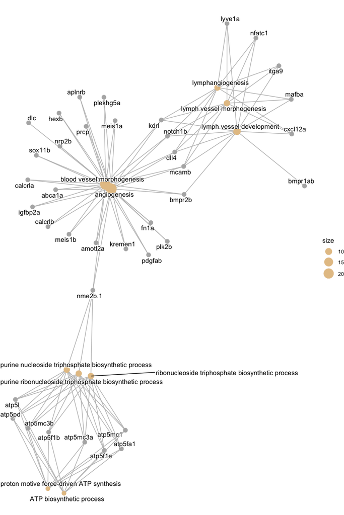

*PDF saved to:* `../output/figure_extended/go_adjpval//hmVEC__mVEC_ego_combined_cnetplot.pdf`

### 1.8.5 ORA ( up ): Barplot

Shows the top enriched GO terms ranked by significance, bar length/colour reflecting adjusted p-value or gene count. **Expected:** terms biologically consistent with the comparison (e.g. vascular/endothelial terms for EC-related contrasts). **Unexpected:** dominance by generic housekeeping terms (translation, metabolism) with no thematic coherence - may indicate a weak or noisy input gene list rather than a real signal.

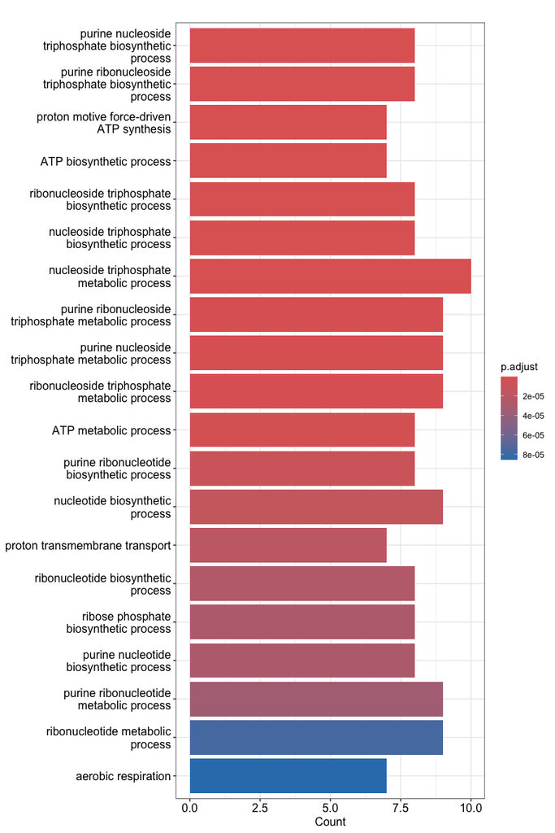

*PDF saved to:* `../output/figure_extended/go_adjpval//hmVEC__mVEC_ego_up_barplot.pdf`

### 1.8.6 ORA ( up ): Dotplot

Adds gene ratio (fraction of input genes hitting each term) as point size, with colour for significance - more informative than the barplot since it shows both effect size and confidence simultaneously. **Expected:** larger, more significant dots clustering around a coherent biological theme. **Unexpected:** significant terms with very small gene ratios (few genes driving a ‘significant’ result) - treat cautiously as potentially fragile.

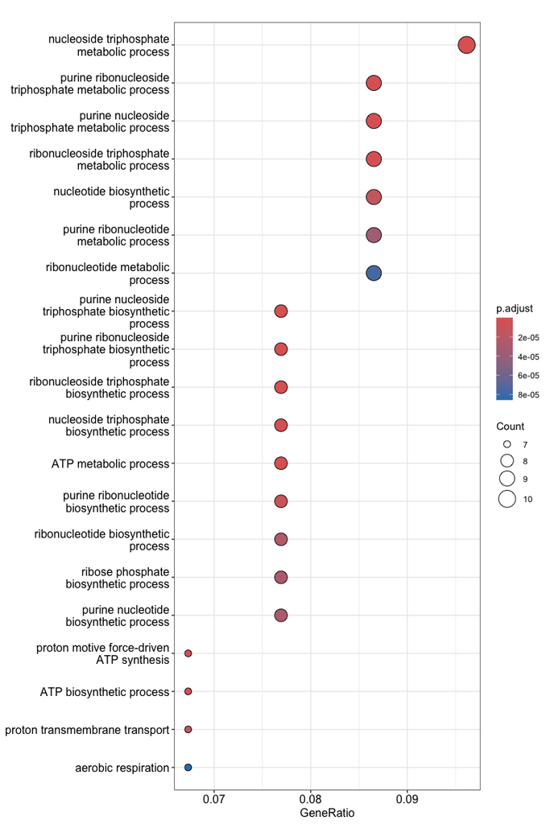

*PDF saved to:* `../output/figure_extended/go_adjpval//hmVEC__mVEC_ego_up_dotplot.pdf`

### 1.8.7 ORA ( up ): Enrichment map

Network graph connecting GO terms that share overlapping genes - clusters of connected terms suggest a shared underlying biological process rather than independent findings. **Expected:** tight clusters of related terms. **Unexpected:** many isolated, unconnected terms, suggesting the significant terms are thematically scattered rather than coherent.

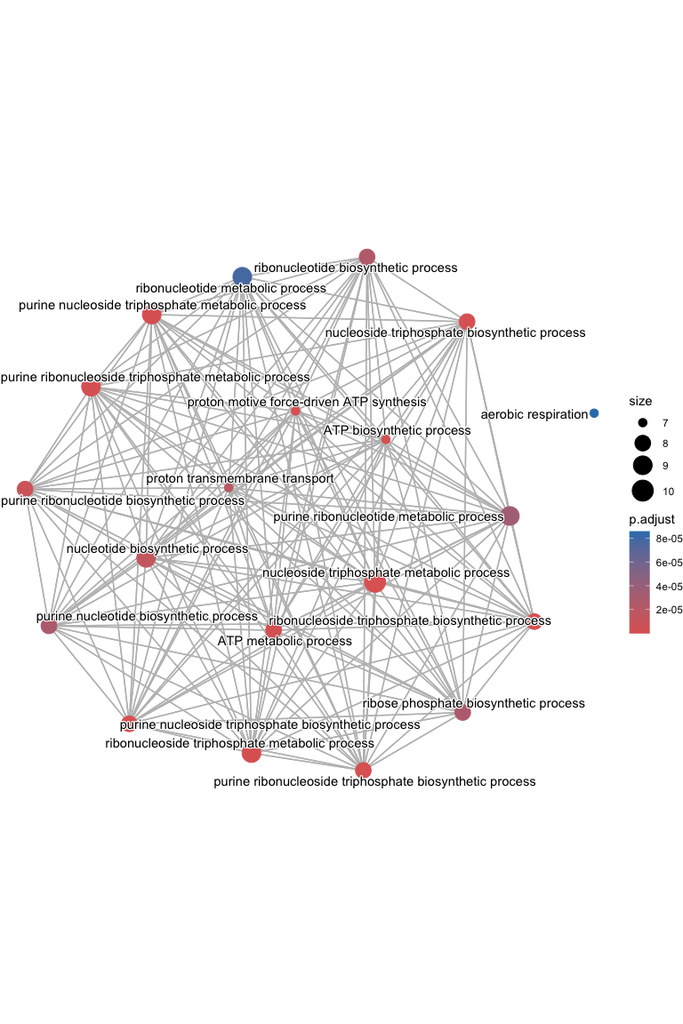

*PDF saved to:* `../output/figure_extended/go_adjpval//hmVEC__mVEC_ego_up_emapplot.pdf`

### 1.8.8 ORA ( up ): Category-gene network

Shows which specific genes drive which enriched terms, useful for tracing a term back to the actual DE genes behind it. **Expected:** recognisable marker genes linking to expected terms. **Unexpected:** a term driven entirely by one or two genes rather than a broad gene set - weaker evidence than a term supported by many genes.

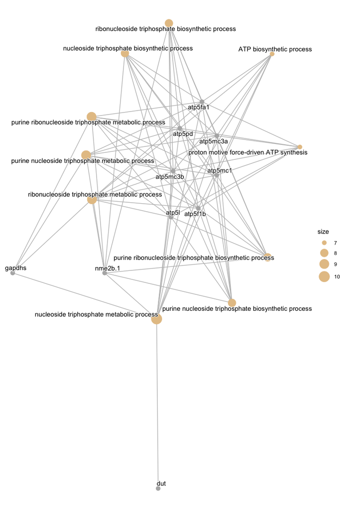

*PDF saved to:* `../output/figure_extended/go_adjpval//hmVEC__mVEC_ego_up_cnetplot.pdf`

### 1.8.9 ORA ( down ): Barplot

Shows the top enriched GO terms ranked by significance, bar length/colour reflecting adjusted p-value or gene count. **Expected:** terms biologically consistent with the comparison (e.g. vascular/endothelial terms for EC-related contrasts). **Unexpected:** dominance by generic housekeeping terms (translation, metabolism) with no thematic coherence - may indicate a weak or noisy input gene list rather than a real signal.

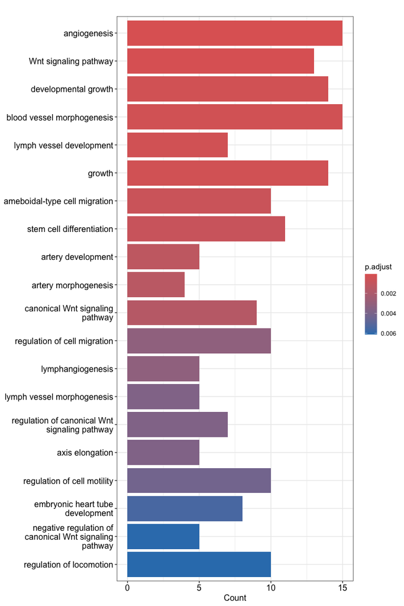

*PDF saved to:* `../output/figure_extended/go_adjpval//hmVEC__mVEC_ego_down_barplot.pdf`

### 1.8.10 ORA ( down ): Dotplot

Adds gene ratio (fraction of input genes hitting each term) as point size, with colour for significance - more informative than the barplot since it shows both effect size and confidence simultaneously. **Expected:** larger, more significant dots clustering around a coherent biological theme. **Unexpected:** significant terms with very small gene ratios (few genes driving a ‘significant’ result) - treat cautiously as potentially fragile.

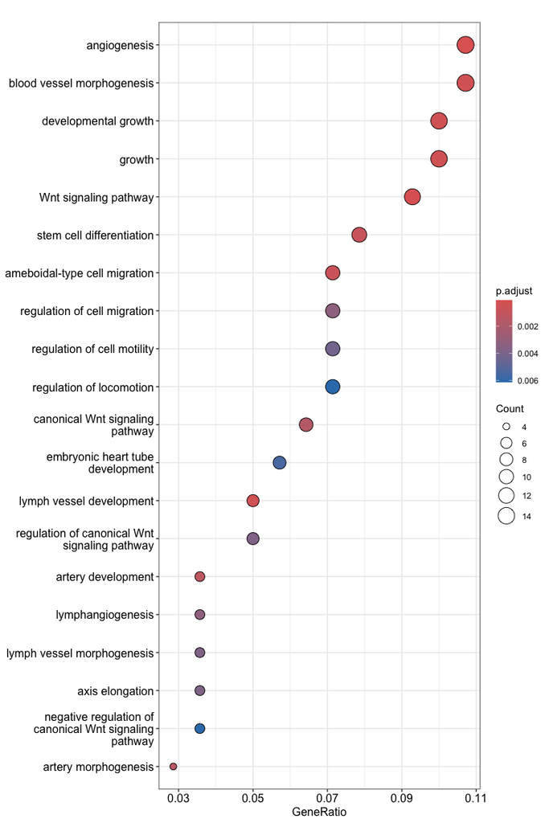

*PDF saved to:* `../output/figure_extended/go_adjpval//hmVEC__mVEC_ego_down_dotplot.pdf`

### 1.8.11 ORA ( down ): Enrichment map

Network graph connecting GO terms that share overlapping genes - clusters of connected terms suggest a shared underlying biological process rather than independent findings. **Expected:** tight clusters of related terms. **Unexpected:** many isolated, unconnected terms, suggesting the significant terms are thematically scattered rather than coherent.

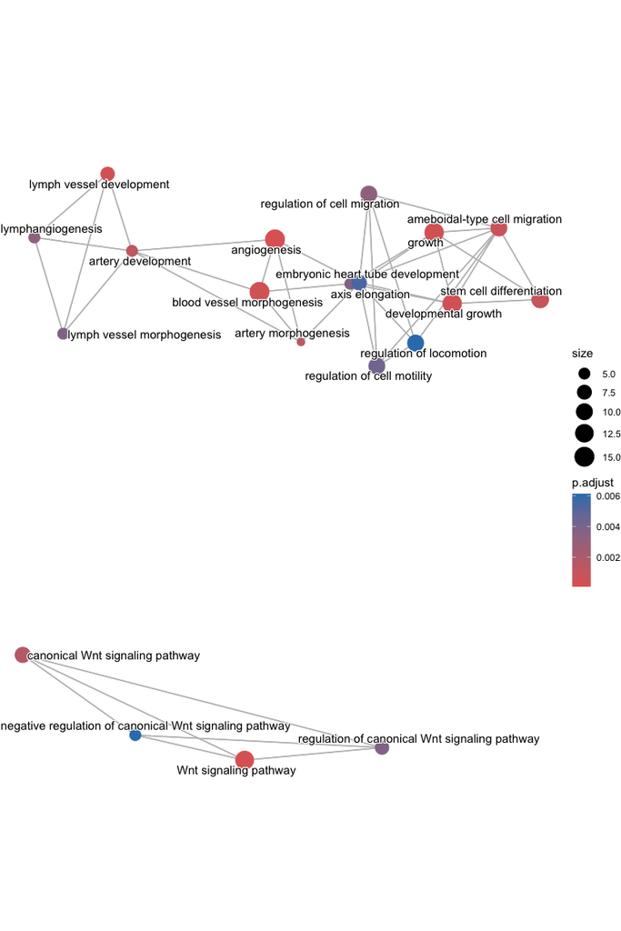

*PDF saved to:* `../output/figure_extended/go_adjpval//hmVEC__mVEC_ego_down_emapplot.pdf`

### 1.8.12 ORA ( down ): Category-gene network

Shows which specific genes drive which enriched terms, useful for tracing a term back to the actual DE genes behind it. **Expected:** recognisable marker genes linking to expected terms. **Unexpected:** a term driven entirely by one or two genes rather than a broad gene set - weaker evidence than a term supported by many genes.

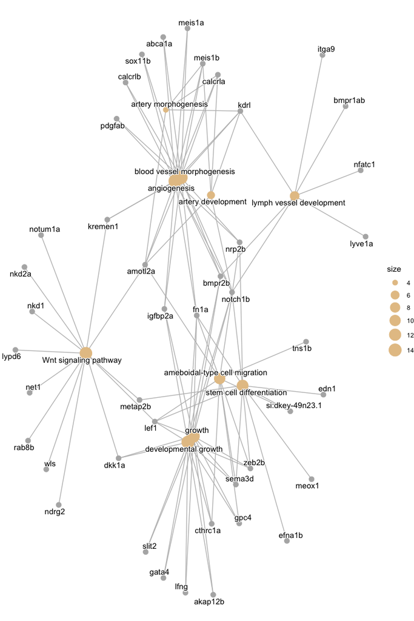

*PDF saved to:* `../output/figure_extended/go_adjpval//hmVEC__mVEC_ego_down_cnetplot.pdf`

**Done:** hmVEC__mVEC

```r
cat("### Custom plots for downregulated genes in mutant vs wildtype\n\n")
```

### 1.8.13 Custom plots for downregulated genes in mutant vs wildtype

```r
ego_vecs <- grouped_vecs_out$ego_result_down@result
ego_vecs$GeneRatio_numeric <- sapply(
    strsplit(ego_vecs$GeneRatio, "/"), function(x) as.numeric(x[1]) / as.numeric(x[2])
    )
ego_vecs_top15_terms <- ego_vecs[
    order(-ego_vecs$GeneRatio_numeric), ][1:15,
    ]
ego_vecs_top15_gene_map <- setNames(strsplit(
    ego_vecs_top15_terms$geneID, "/"), ego_vecs_top15_terms$Description
    )
ego_vecs_top15_gene_list <- unique(unlist(unname(ego_vecs_top15_gene_map)))

ego_vecs_top15_pathways <- data.frame(ego_vecs$ID, ego_vecs$Description, ego_vecs$geneID)

ego_vecs_top15_gene_list <- ego_vecs_top15_gene_list[
    grep(":", ego_vecs_top15_gene_list, invert=TRUE)
    ]

cat("\n\nDotplots of gene ratio top 15 only.\n\n")
```

Dotplots of gene ratio top 15 only.

```r
cat("Adds gene ratio (fraction of input genes hitting each term) as point size, with colour ",
    "for significance - more informative than the barplot since it shows both effect size and ",
    "confidence simultaneously. **Expected:** larger, more significant dots clustering around a ",
    "coherent biological theme. **Unexpected:** significant terms with very small gene ratios ",
    "(few genes driving a 'significant' result) - treat cautiously as potentially fragile.\n\n")
```

Adds gene ratio (fraction of input genes hitting each term) as point size, with colour for significance - more informative than the barplot since it shows both effect size and confidence simultaneously. **Expected:** larger, more significant dots clustering around a coherent biological theme. **Unexpected:** significant terms with very small gene ratios (few genes driving a ‘significant’ result) - treat cautiously as potentially fragile.

```r
cat("\n\n_Suggested figure legend:_ Dotplot shows the effect size and confidence simultaneously for differentially expressed genes associated with enriched GO terms. Units on the horizontal axis correspond to the fraction of input genes which hit each GO term. Point size corresponds to the quantity of terms, and point colour corresponds to adjusted p values. Top 15 GO terms by gene ratio are shown.\n\n")
```

[output not shown]

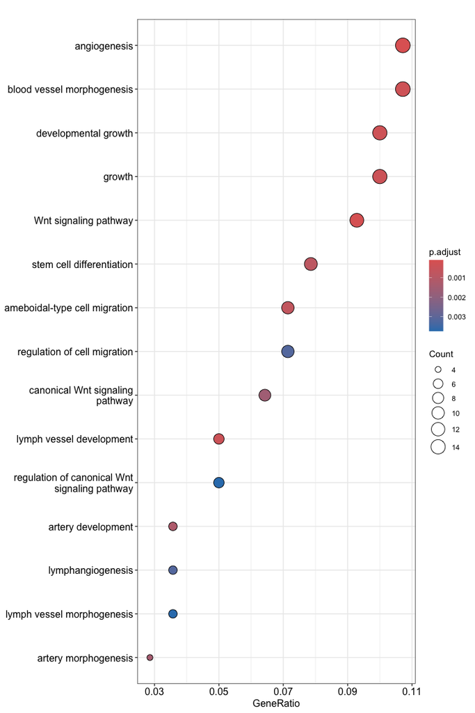

```r
plt_name <- "top15_VECs_GO_pathways_downregulated_generatio_dotplot"
plt <- dotplot(grouped_vecs_out$ego_result_down, showCategory=15)
print(plt)
```

```r
save_plot_custom(plt, plt_name)
```

*PDF saved to:* `../output/figure_extended/go_adjpval//top15_VECs_GO_pathways_downregulated_generatio_dotplot.pdf`

```r
data_vecs <- data[, (data$L3_celltype == "hmVEC" | data$L3_celltype == "mVEC")]
data_vecs$Genotype <- gsub("meox1_mutant", "Mutant", data_vecs$Genotype)
data_vecs$Genotype <- gsub("wildtype", "WT", data_vecs$Genotype)
data_vecs$Genotype <- factor(
    data_vecs$Genotype,
    levels = c("WT", "Mutant")
)

cat("\n\nDotplots of gene expression (key pathways).\n\n")
```

Dotplots of gene expression (key pathways).

```r
cat("For plot expansion, settled on these:\n\n
1. selected top 15 pathways as a cutoff\n
2. extracted the genes associated with these\n
3. removed genes with the `[a-z]+:` prefix\n
4. selected genes associated with key pathways and added meox1\n
5. plotted dotplots on the remainder\n\n

Attempted heatmaps, not very useful.\n\n")
```

For plot expansion, settled on these:

1. selected top 15 pathways as a cutoff
2. extracted the genes associated with these
3. removed genes with the `[a-z]+:` prefix
4. selected genes associated with key pathways and added meox1
5. plotted dotplots on the remainder

Attempted heatmaps, not very useful.

```r
cat("\n\n_Suggested figure legend:_ Dotplot shows the scaled expression level for genes from enriched GO terms. Units on the horizontal axis correspond to the genotypes. Point size corresponds to the percent of expression in each cell group, and point colour corresponds to average expression z-scores. Genes were selected by membership in key pathways detected by gene enrichment and ontology analyses: sprouting angiogenesis. In addition, meox1 is shown for reference.\n\n")
```

*Suggested figure legend:* Dotplot shows the scaled expression level for genes from enriched GO terms. Units on the horizontal axis correspond to the genotypes. Point size corresponds to the percent of expression in each cell group, and point colour corresponds to average expression z-scores. Genes were selected by membership in key pathways detected by gene enrichment and ontology analyses: sprouting angiogenesis. In addition, meox1 is shown for reference.

```r
cat("\n\n_Caution against overinterpretation:_ Not an invalid result, but the scale may exaggerate the magnitude of difference.\n
The dotplots look very clean but theres some important nuance\n
1. the pathway genes are sourced from DEG so these would naturally be different
2. the expression values on the dotplot are z-score values and the relatively low scale indicates that the magnitude of the expression isnt massively different (but still different enough)\n\n")
```

*Caution against overinterpretation:* Not an invalid result, but the scale may exaggerate the magnitude of difference.

The dotplots look very clean but theres some important nuance

1. the pathway genes are sourced from DEG so these would naturally be different
2. the expression values on the dotplot are z-score values and the relatively low scale indicates that the magnitude of the expression isnt massively different (but still different enough)

```r
# plot gene expr
plt_name <- "top15_VECs_GO_pathways_downregulated_geneexpr_dotplot_curated"
ego_vecs_pathways <- c(
    "sprouting angiogenesis"
    )
ego_vecs_selected_rows <- ego_vecs_top15_pathways[
    ego_vecs_top15_pathways$ego_vecs.Description %in% ego_vecs_pathways,
    ]
ego_vecs_genes_per_pathway <- setNames(
    strsplit(ego_vecs_selected_rows$ego_vecs.geneID, "/"),
    ego_vecs_selected_rows$ego_vecs.Description
    )
ego_vecs_genes_per_pathway <- c(unique(
    unlist(ego_vecs_genes_per_pathway)
    ), "meox1")
ego_vecs_genes_per_pathway <- ego_vecs_genes_per_pathway[
    grep(":", ego_vecs_genes_per_pathway, invert=TRUE)
    ]
cat("\nGene quantity: ", length(ego_vecs_genes_per_pathway))
```

Gene quantity: 6

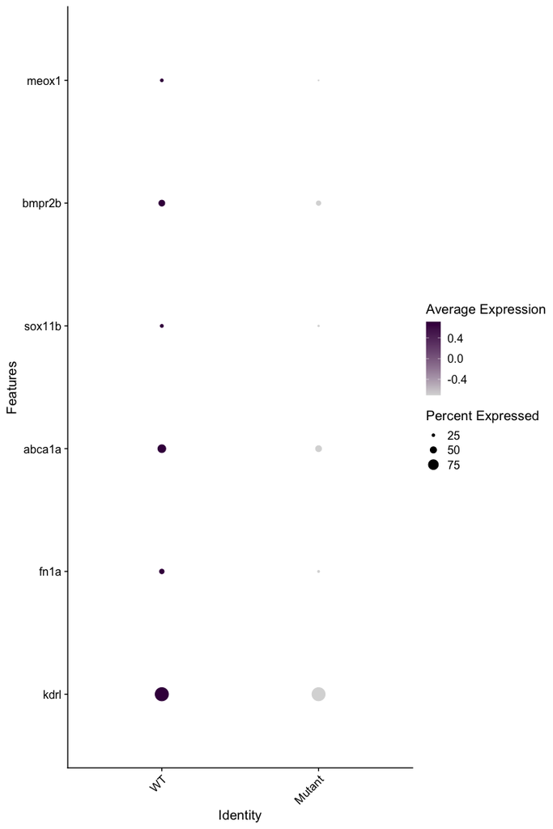

```r
plt <- DotPlot(data_vecs, features=ego_vecs_genes_per_pathway,
    group.by="Genotype", cols=c("#d9d9d9",  "#40004b")
    ) +
    coord_flip() +
    theme(axis.text.x = element_text(angle = 45, vjust = 1, hjust = 1))
print(plt)
```

```r
save_plot_custom(plt, plt_name, height=12, width=4)
```

*PDF saved to:* `../output/figure_extended/go_adjpval//top15_VECs_GO_pathways_downregulated_geneexpr_dotplot_curated.pdf`

```r
cat("\n\n_Suggested figure legend:_ Violin plot shows the log2 normalised expression level for differentially expressed genes associated with enriched GO terms. Units on the horizontal axis correspond to the genotypes. Genes were selected by membership in key pathways detected by gene enrichment and ontology analyses: sprouting angiogenesis. In addition, meox1 is shown for reference.\n\n")
```

*Suggested figure legend:* Violin plot shows the log2 normalised expression level for differentially expressed genes associated with enriched GO terms. Units on the horizontal axis correspond to the genotypes. Genes were selected by membership in key pathways detected by gene enrichment and ontology analyses: sprouting angiogenesis. In addition, meox1 is shown for reference.

```r
cat("\n_Tyrone: Not every single canonical gene associated with the pathway will be shown. It is a function of the data, only the differentially expressed genes associated with the GO term will be shown. Also, I trimmed this down to sprouting angiogenesis only to get a manageable gene list, but its worth noting that their associated genes in the context of this dataset are a full subset of angiogenesis and blood vessel morphogenesis pathways._\n\n")
```

*Tyrone: Not every single canonical gene associated with the pathway will be shown. It is a function of the data, only the differentially expressed genes associated with the GO term will be shown. Also, I trimmed this down to sprouting angiogenesis only to get a manageable gene list, but its worth noting that their associated genes in the context of this dataset are a full subset of angiogenesis and blood vessel morphogenesis pathways.*

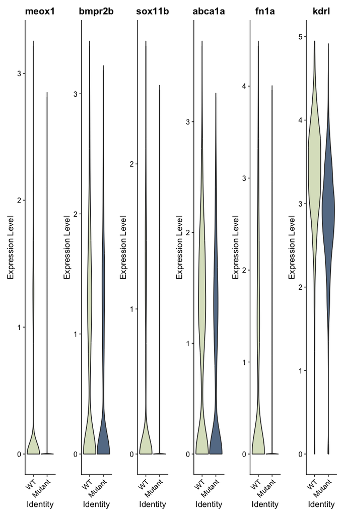

```r
plt_name <- "top15_VECs_GO_pathways_downregulated_geneexpr_vlnplot_curated"
plt <- VlnPlot(
    data_vecs,
    features = rev(ego_vecs_genes_per_pathway),
    group.by = "Genotype",
    pt.size = 0,
    ncol = 6,
    flip = TRUE,
    cols = c("#dbe2c6", "#657c95")
) + scale_fill_manual(values = c("#dbe2c6", "#657c95")) +
    theme(axis.text.x = element_text(angle = 45, vjust = 1, hjust = 1))
print(plt)
```

```r
save_plot_custom(plt, plt_name, height=16, width=16)
```

*PDF saved to:* `../output/figure_extended/go_adjpval//top15_VECs_GO_pathways_downregulated_geneexpr_vlnplot_curated.pdf`

```r
singles_hmVEC_out <- run_go(singles_hmVEC, data_name="hmVEC")
```

## 1.9 GO analysis: hmVEC

Input genes: 14308

**ORA input genes:** combined = 29 up = 8 down = 21

**ORA (combined):** 146 terms **ORA (up):** 37 terms **ORA (down):** 115 terms

**ORA significant terms:** combined = 0 , up = 0 , down = 3

*No ORA ( combined ) terms found for hmVEC - skipping ORA ( combined ) plots*

*No ORA ( up ) terms found for hmVEC - skipping ORA ( up ) plots*

### 1.9.1 ORA ( down ): Barplot

Shows the top enriched GO terms ranked by significance, bar length/colour reflecting adjusted p-value or gene count. **Expected:** terms biologically consistent with the comparison (e.g. vascular/endothelial terms for EC-related contrasts). **Unexpected:** dominance by generic housekeeping terms (translation, metabolism) with no thematic coherence - may indicate a weak or noisy input gene list rather than a real signal.

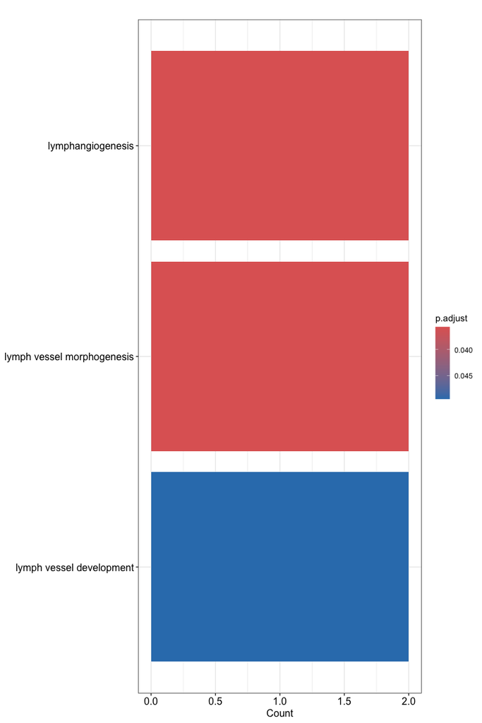

*PDF saved to:* `../output/figure_extended/go_adjpval//hmVEC_ego_down_barplot.pdf`

### 1.9.2 ORA ( down ): Dotplot

Adds gene ratio (fraction of input genes hitting each term) as point size, with colour for significance - more informative than the barplot since it shows both effect size and confidence simultaneously. **Expected:** larger, more significant dots clustering around a coherent biological theme. **Unexpected:** significant terms with very small gene ratios (few genes driving a ‘significant’ result) - treat cautiously as potentially fragile.

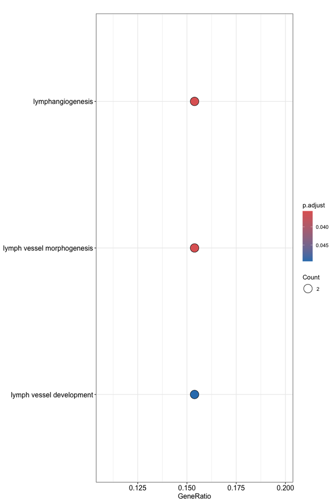

*PDF saved to:* `../output/figure_extended/go_adjpval//hmVEC_ego_down_dotplot.pdf`

### 1.9.3 ORA ( down ): Enrichment map

Network graph connecting GO terms that share overlapping genes - clusters of connected terms suggest a shared underlying biological process rather than independent findings. **Expected:** tight clusters of related terms. **Unexpected:** many isolated, unconnected terms, suggesting the significant terms are thematically scattered rather than coherent.

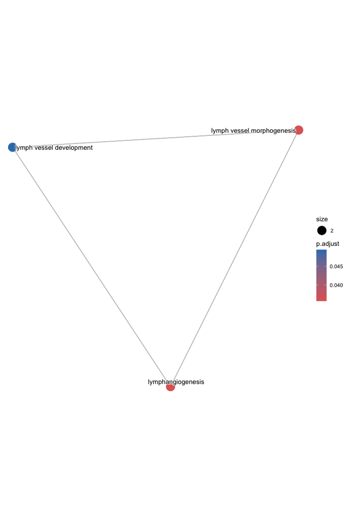

*PDF saved to:* `../output/figure_extended/go_adjpval//hmVEC_ego_down_emapplot.pdf`

### 1.9.4 ORA ( down ): Category-gene network

Shows which specific genes drive which enriched terms, useful for tracing a term back to the actual DE genes behind it. **Expected:** recognisable marker genes linking to expected terms. **Unexpected:** a term driven entirely by one or two genes rather than a broad gene set - weaker evidence than a term supported by many genes.

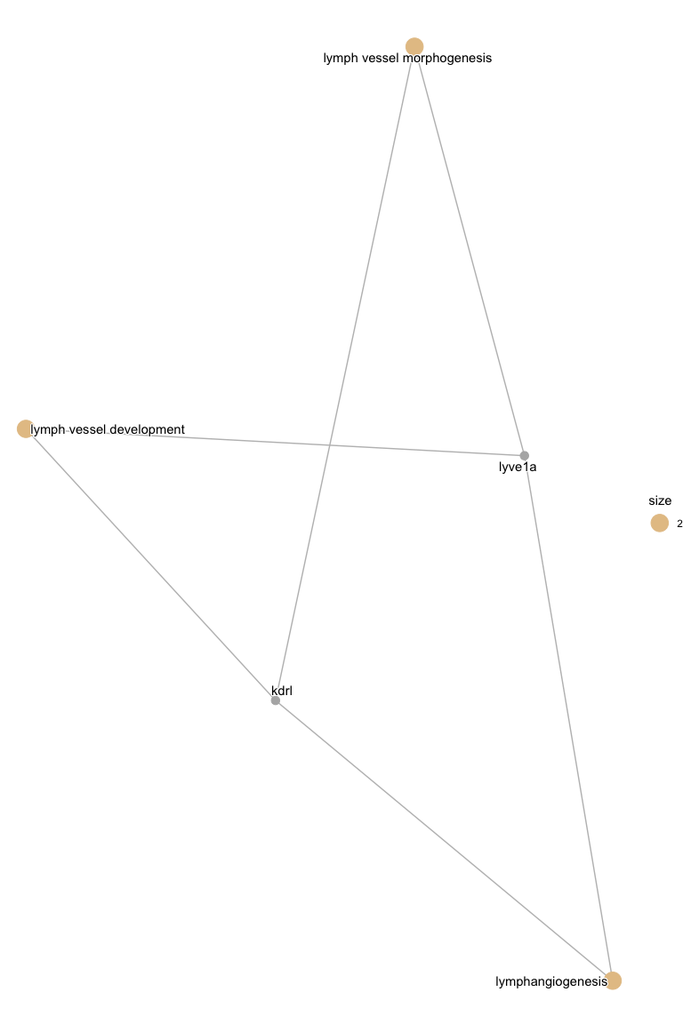

*PDF saved to:* `../output/figure_extended/go_adjpval//hmVEC_ego_down_cnetplot.pdf`

**Done:** hmVEC

```r
singles_mVEC_out <- run_go(singles_mVEC, data_name="mVEC")
```

## 1.10 GO analysis: mVEC

Input genes: 14187

**ORA input genes:** combined = 112 up = 44 down = 68

**ORA (combined):** 658 terms **ORA (up):** 258 terms **ORA (down):** 479 terms

**ORA significant terms:** combined = 45 , up = 39 , down = 45

### 1.10.1 ORA ( combined ): Barplot

Shows the top enriched GO terms ranked by significance, bar length/colour reflecting adjusted p-value or gene count. **Expected:** terms biologically consistent with the comparison (e.g. vascular/endothelial terms for EC-related contrasts). **Unexpected:** dominance by generic housekeeping terms (translation, metabolism) with no thematic coherence - may indicate a weak or noisy input gene list rather than a real signal.

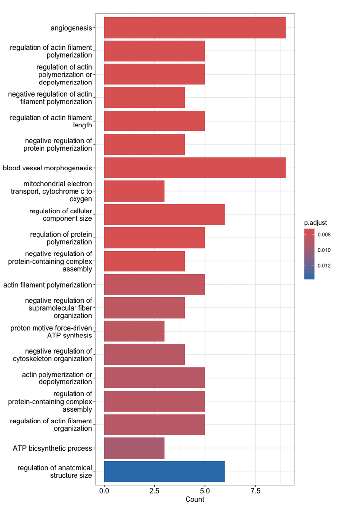

*PDF saved to:* `../output/figure_extended/go_adjpval//mVEC_ego_combined_barplot.pdf`

### 1.10.2 ORA ( combined ): Dotplot

Adds gene ratio (fraction of input genes hitting each term) as point size, with colour for significance - more informative than the barplot since it shows both effect size and confidence simultaneously. **Expected:** larger, more significant dots clustering around a coherent biological theme. **Unexpected:** significant terms with very small gene ratios (few genes driving a ‘significant’ result) - treat cautiously as potentially fragile.

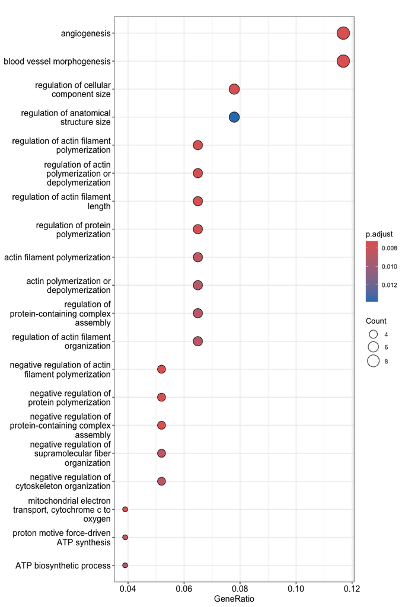

*PDF saved to:* `../output/figure_extended/go_adjpval//mVEC_ego_combined_dotplot.pdf`

### 1.10.3 ORA ( combined ): Enrichment map

Network graph connecting GO terms that share overlapping genes - clusters of connected terms suggest a shared underlying biological process rather than independent findings. **Expected:** tight clusters of related terms. **Unexpected:** many isolated, unconnected terms, suggesting the significant terms are thematically scattered rather than coherent.

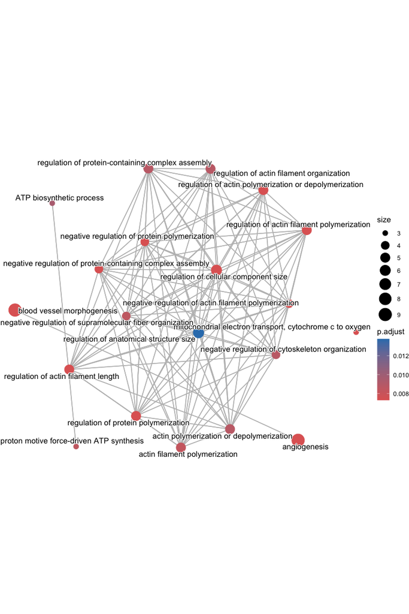

*PDF saved to:* `../output/figure_extended/go_adjpval//mVEC_ego_combined_emapplot.pdf`

### 1.10.4 ORA ( combined ): Category-gene network

Shows which specific genes drive which enriched terms, useful for tracing a term back to the actual DE genes behind it. **Expected:** recognisable marker genes linking to expected terms. **Unexpected:** a term driven entirely by one or two genes rather than a broad gene set - weaker evidence than a term supported by many genes.

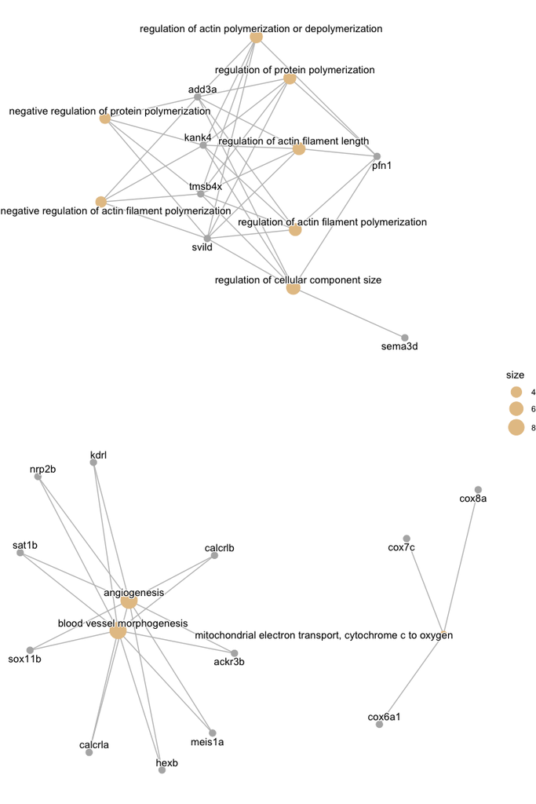

*PDF saved to:* `../output/figure_extended/go_adjpval//mVEC_ego_combined_cnetplot.pdf`

### 1.10.5 ORA ( up ): Barplot

Shows the top enriched GO terms ranked by significance, bar length/colour reflecting adjusted p-value or gene count. **Expected:** terms biologically consistent with the comparison (e.g. vascular/endothelial terms for EC-related contrasts). **Unexpected:** dominance by generic housekeeping terms (translation, metabolism) with no thematic coherence - may indicate a weak or noisy input gene list rather than a real signal.

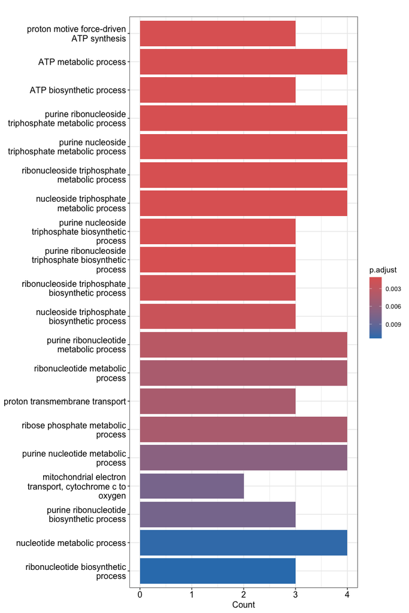

*PDF saved to:* `../output/figure_extended/go_adjpval//mVEC_ego_up_barplot.pdf`

### 1.10.6 ORA ( up ): Dotplot

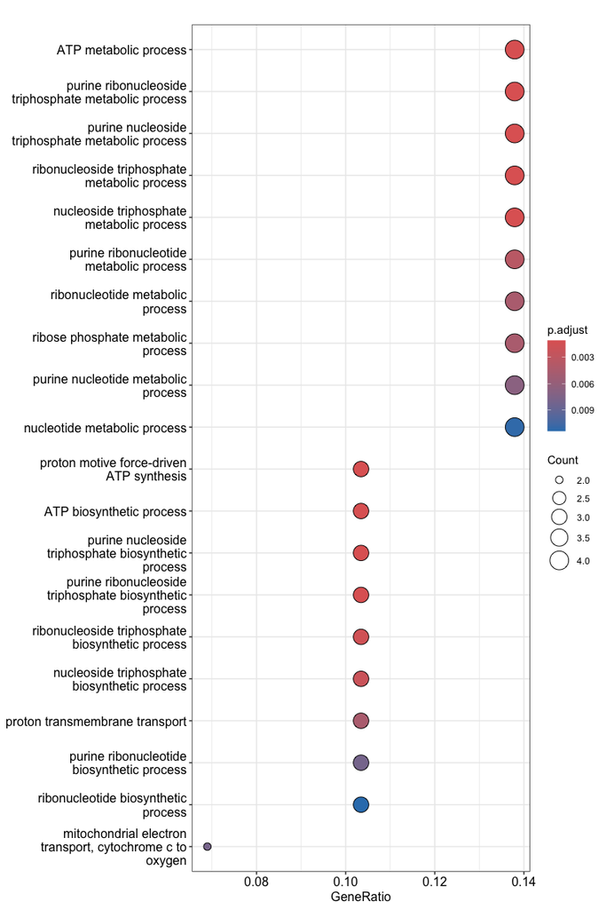

*PDF saved to:* `../output/figure_extended/go_adjpval//mVEC_ego_up_dotplot.pdf`

### 1.10.7 ORA ( up ): Enrichment map

Network graph connecting GO terms that share overlapping genes - clusters of connected terms suggest a shared underlying biological process rather than independent findings. **Expected:** tight clusters of related terms. **Unexpected:** many isolated, unconnected terms, suggesting the significant terms are thematically scattered rather than coherent.

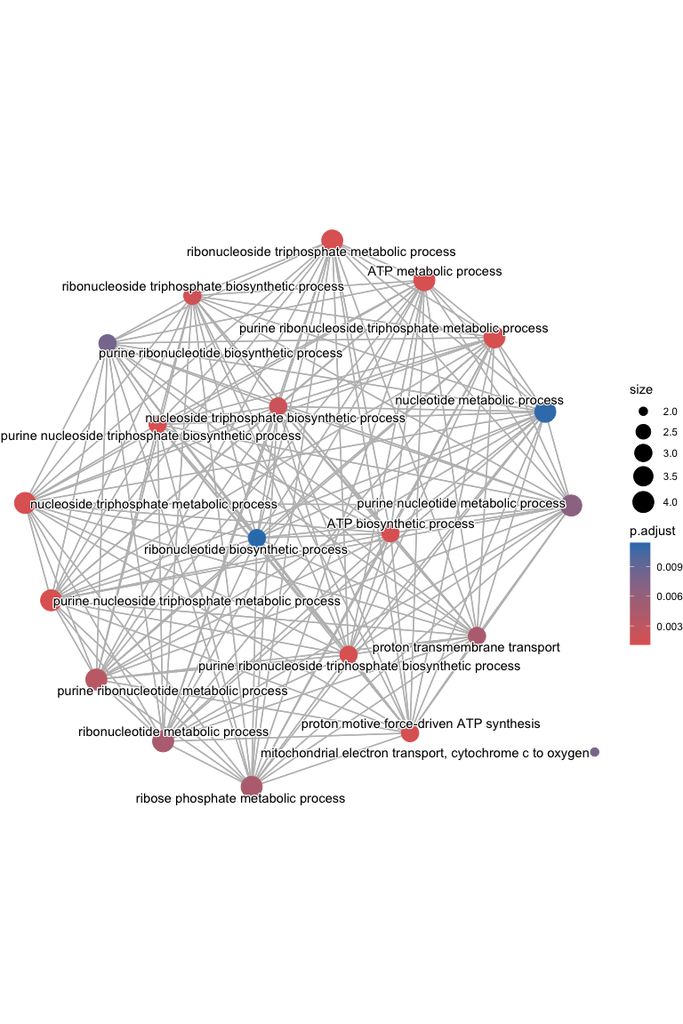

*PDF saved to:* `../output/figure_extended/go_adjpval//mVEC_ego_up_emapplot.pdf`

### 1.10.8 ORA ( up ): Category-gene network

Shows which specific genes drive which enriched terms, useful for tracing a term back to the actual DE genes behind it. **Expected:** recognisable marker genes linking to expected terms. **Unexpected:** a term driven entirely by one or two genes rather than a broad gene set - weaker evidence than a term supported by many genes.

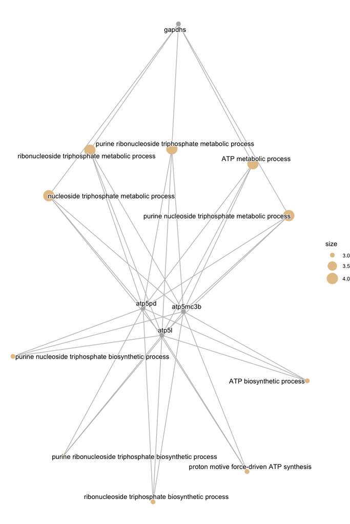

*PDF saved to:* `../output/figure_extended/go_adjpval//mVEC_ego_up_cnetplot.pdf`

### 1.10.9 ORA ( down ): Barplot

Shows the top enriched GO terms ranked by significance, bar length/colour reflecting adjusted p-value or gene count. **Expected:** terms biologically consistent with the comparison (e.g. vascular/endothelial terms for EC-related contrasts). **Unexpected:** dominance by generic housekeeping terms (translation, metabolism) with no thematic coherence - may indicate a weak or noisy input gene list rather than a real signal.

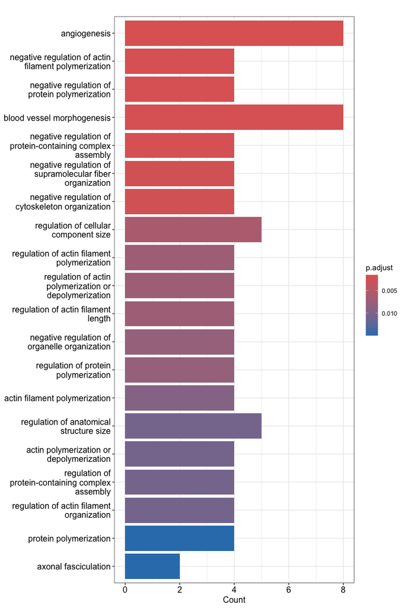

*PDF saved to:* `../output/figure_extended/go_adjpval//mVEC_ego_down_barplot.pdf`

### 1.10.10 ORA ( down ): Dotplot

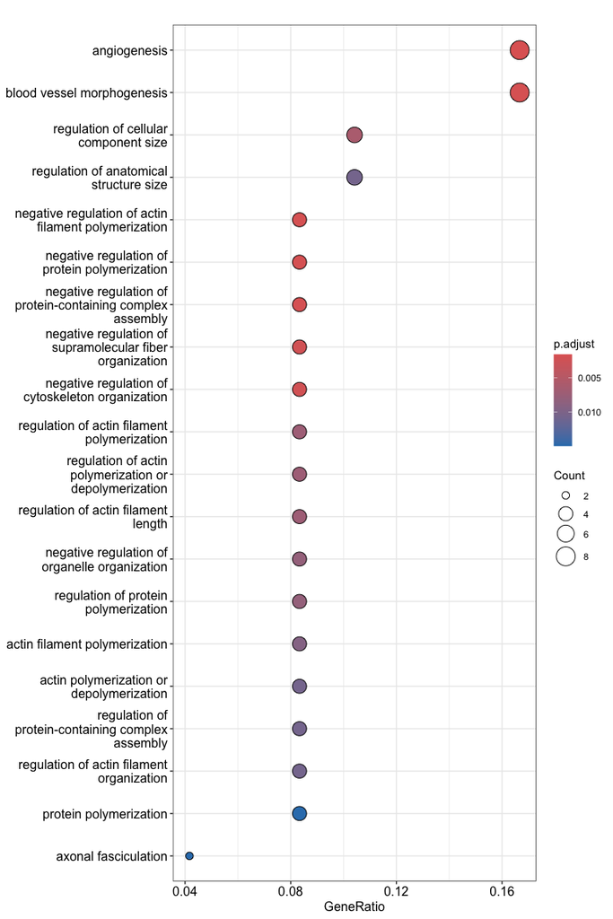

*PDF saved to:* `../output/figure_extended/go_adjpval//mVEC_ego_down_dotplot.pdf`

### 1.10.11 ORA ( down ): Enrichment map

Network graph connecting GO terms that share overlapping genes - clusters of connected terms suggest a shared underlying biological process rather than independent findings. **Expected:** tight clusters of related terms. **Unexpected:** many isolated, unconnected terms, suggesting the significant terms are thematically scattered rather than coherent.

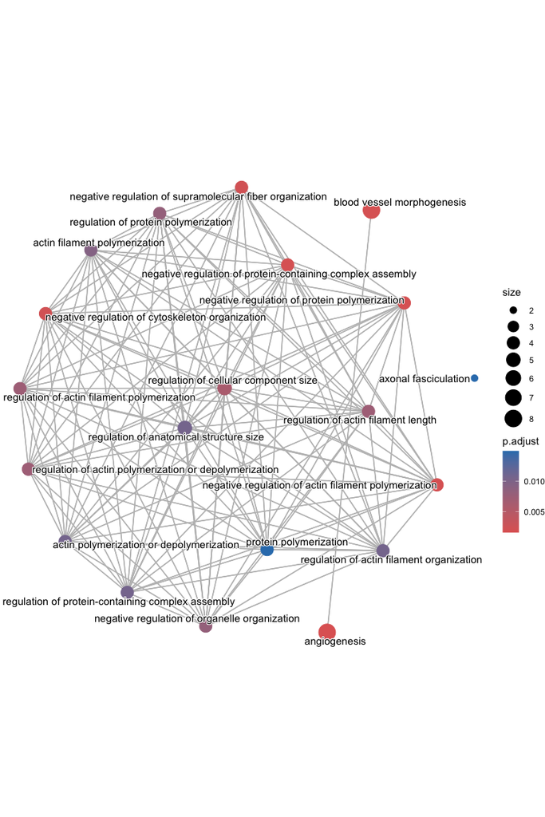

*PDF saved to:* `../output/figure_extended/go_adjpval//mVEC_ego_down_emapplot.pdf`

### 1.10.12 ORA ( down ): Category-gene network

Shows which specific genes drive which enriched terms, useful for tracing a term back to the actual DE genes behind it. **Expected:** recognisable marker genes linking to expected terms. **Unexpected:** a term driven entirely by one or two genes rather than a broad gene set - weaker evidence than a term supported by many genes.

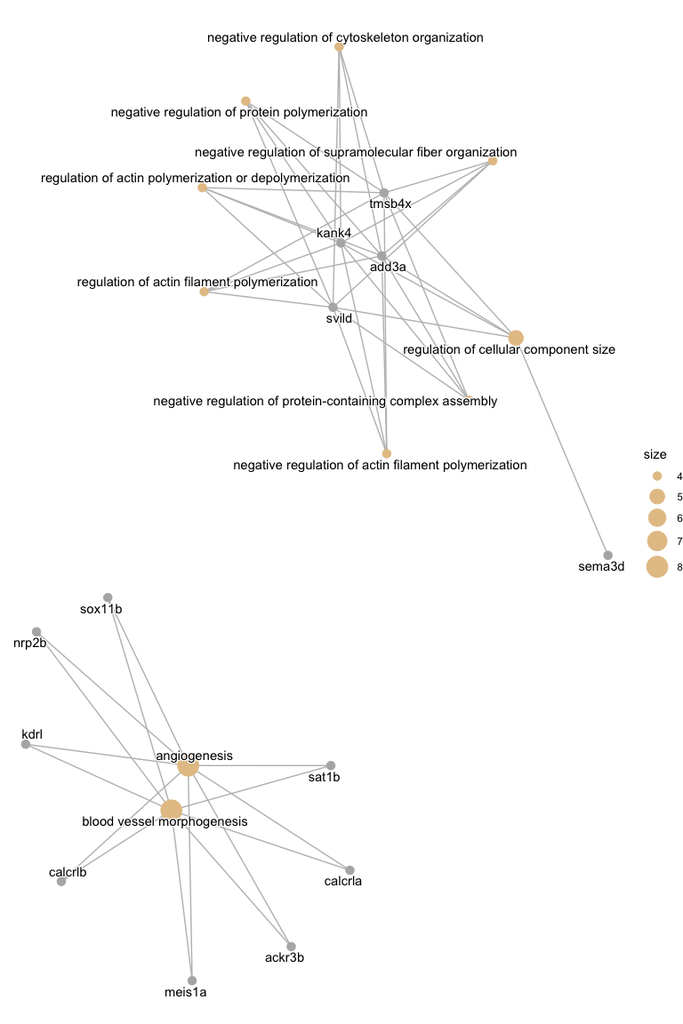

*PDF saved to:* `../output/figure_extended/go_adjpval//mVEC_ego_down_cnetplot.pdf`

**Done:** mVEC

## 1.11 For developers

Sample run command:

```bash
Rscript -e "
rmarkdown::render(
  'meox1_goanalysis_adjpval.Rmd',
  output_file = './meox1_goanalysis_adjpval.html'
)
"
```

Reference-only: an earlier version of `run_go()` also ran FGSEA + UpSet overlap plots alongside ORA. Kept here disabled (`eval=FALSE`) since the current pipeline above dropped FGSEA/UpSet for this adjpval variant - restore by copying this chunk over the “wrap” chunk above if FGSEA comparison is needed again.

```r
run_go <- function(data, data_name) {
    cat("\n\n## GO analysis:", data_name, "\n\n")
    cat("Input genes:", nrow(data), "\n\n")

    # FGSEA
    gene_list <- data$avg_log2FC
    names(gene_list) <- data$Gene
    gene_list <- sort(gene_list, decreasing = TRUE)

    fgsea_result <- gseGO(
        geneList = gene_list,
        OrgDb = org.Dr.eg.db,
        keyType = "SYMBOL",
        ont = "BP",
        pAdjustMethod = "BH"
    )

    n_fgsea_terms <- nrow(fgsea_result@result)

    # enrichGO - now split into up/down, plus combined kept for FGSEA comparison
    sig_gene_list      <- data$Gene[data$p_val_adj < 0.05]
    sig_gene_list_up    <- data$Gene[data$p_val_adj < 0.05 & data$avg_log2FC > 0]
    sig_gene_list_down  <- data$Gene[data$p_val_adj < 0.05 & data$avg_log2FC < 0]

    cat("**ORA input genes:** combined =", length(sig_gene_list),
        "&nbsp;&nbsp; up =", length(sig_gene_list_up),
        "&nbsp;&nbsp; down =", length(sig_gene_list_down), "\n\n")

    run_ora <- function(genes) {
        if (length(genes) < 2) return(NULL)
        enrichGO(
            gene = genes,
            keyType = "SYMBOL",
            OrgDb = org.Dr.eg.db,
            ont = "BP",
            pAdjustMethod = "BH",
            pvalueCutoff = 0.05,
            qvalueCutoff = 0.05,
            readable = TRUE
        )
    }

    ego_result      <- run_ora(sig_gene_list)
    ego_result_up   <- run_ora(sig_gene_list_up)
    ego_result_down <- run_ora(sig_gene_list_down)

    n_ora_terms      <- if (!is.null(ego_result))      nrow(ego_result@result)      else 0
    n_ora_up_terms   <- if (!is.null(ego_result_up))   nrow(ego_result_up@result)   else 0
    n_ora_down_terms <- if (!is.null(ego_result_down)) nrow(ego_result_down@result) else 0

    cat("**FGSEA:**", n_fgsea_terms, "terms tested/returned &nbsp;&nbsp; ",
        "**ORA (combined):**", n_ora_terms, "terms &nbsp;&nbsp; ",
        "**ORA (up):**", n_ora_up_terms, "terms &nbsp;&nbsp; ",
        "**ORA (down):**", n_ora_down_terms, "terms\n\n")

    # significant terms - guard against empty results
    fgsea_sig_terms <- if (n_fgsea_terms > 0) {
        fgsea_result@result$ID[fgsea_result@result$p.adjust < 0.05]
    } else character(0)

    ora_sig_terms <- if (n_ora_terms > 0) {
        ego_result@result$ID[ego_result@result$p.adjust < 0.05]
    } else character(0)

    ora_up_sig_terms <- if (n_ora_up_terms > 0) {
        ego_result_up@result$ID[ego_result_up@result$p.adjust < 0.05]
    } else character(0)

    ora_down_sig_terms <- if (n_ora_down_terms > 0) {
        ego_result_down@result$ID[ego_result_down@result$p.adjust < 0.05]
    } else character(0)

    fgsea_up <- if (n_fgsea_terms > 0) {
        fgsea_result@result$ID[fgsea_result@result$p.adjust < 0.05 & fgsea_result@result$NES > 0]
    } else character(0)

    fgsea_down <- if (n_fgsea_terms > 0) {
        fgsea_result@result$ID[fgsea_result@result$p.adjust < 0.05 & fgsea_result@result$NES < 0]
    } else character(0)

    cat("**FGSEA significant terms** (p.adjust < 0.05):", length(fgsea_sig_terms),
        "(", length(fgsea_up), "up /", length(fgsea_down), "down) &nbsp;&nbsp; ",
        "**ORA significant terms:** combined =", length(ora_sig_terms),
        ", up =", length(ora_up_sig_terms), ", down =", length(ora_down_sig_terms), "\n\n")

    if (length(union(fgsea_sig_terms, ora_sig_terms)) > 0) {
        overlap_n <- length(intersect(fgsea_sig_terms, ora_sig_terms))
        jaccard <- overlap_n / length(union(fgsea_sig_terms, ora_sig_terms))
        cat("**FGSEA/ORA (combined) overlap:**", overlap_n, "shared terms, Jaccard =", round(jaccard, 4), "\n\n")
    } else {
        cat("*No significant terms in either FGSEA or ORA (combined) for", data_name, "- skipping overlap calc*\n\n")
    }

    # helper to save a ggplot object in both pdf and png, log the pdf path clearly
    save_plot <- function(plt, plot_name, width = 8, height = 12) {
        pdf_path <- paste0(outfile_dir, "/", data_name, "_", plot_name, ".pdf")
        png_path <- paste0(outfile_dir, "/", data_name, "_", plot_name, ".png")
        ggsave(filename = pdf_path, plot = plt, width = width, height = height)
        ggsave(filename = png_path, plot = plt, width = width, height = height)
        cat("*PDF saved to:*", paste0("`", pdf_path, "`"), "\n\n")
    }

    # separate helper for UpSetR objects - these are NOT ggplot objects,
    # ggsave() fails on them (no grid.draw method for class "upset")
    save_upset_plot <- function(plt, plot_name, width = 8, height = 6) {
        pdf_path <- paste0(outfile_dir, "/", data_name, "_", plot_name, ".pdf")
        png_path <- paste0(outfile_dir, "/", data_name, "_", plot_name, ".png")

        pdf(pdf_path, width = width, height = height)
        print(plt)
        dev.off()

        png(png_path, width = width, height = height, units = "in", res = 300)
        print(plt)
        dev.off()

        cat("*PDF saved to:*", paste0("`", pdf_path, "`"), "\n\n")
    }

    # reusable block for one ORA result (combined / up / down) - avoids
    # triplicating the same five-plot sequence three times over
    run_ora_plots <- function(ego_res, n_terms, block_label, file_tag) {
        if (n_terms == 0 || dim(ego_res)[1] == 0) {
            cat("*No ORA (", block_label, ") terms found for", data_name,
                "- skipping ORA (", block_label, ") plots*\n\n")
            return(invisible(NULL))
        }

        cat("### ORA (", block_label, "): Barplot\n\n")
        cat("Shows the top enriched GO terms ranked by significance, bar length/colour reflecting ",
            "adjusted p-value or gene count. **Expected:** terms biologically consistent with the ",
            "comparison (e.g. vascular/endothelial terms for EC-related contrasts). **Unexpected:** ",
            "dominance by generic housekeeping terms (translation, metabolism) with no thematic ",
            "coherence - may indicate a weak or noisy input gene list rather than a real signal.\n\n")
        plt <- barplot(ego_res, showCategory = 20)
        print(plt)
        save_plot(plt, paste0("ego_", file_tag, "_barplot"))
```

```r
        cat("### ORA (", block_label, "): Dotplot\n\n")
        cat("Adds gene ratio (fraction of input genes hitting each term) as point size, with colour ",
            "for significance - more informative than the barplot since it shows both effect size and ",
            "confidence simultaneously. **Expected:** larger, more significant dots clustering around a ",
            "coherent biological theme. **Unexpected:** significant terms with very small gene ratios ",
            "(few genes driving a 'significant' result) - treat cautiously as potentially fragile.\n\n")
        plt <- dotplot(ego_res, showCategory = 20)
        print(plt)
        save_plot(plt, paste0("ego_", file_tag, "_dotplot"))

        cat("### ORA (", block_label, "): Enrichment map\n\n")
        cat("Network graph connecting GO terms that share overlapping genes - clusters of connected ",
            "terms suggest a shared underlying biological process rather than independent findings. ",
            "**Expected:** tight clusters of related terms. **Unexpected:** many isolated, unconnected ",
            "terms, suggesting the significant terms are thematically scattered rather than coherent.\n\n")
        ego_res_sim <- pairwise_termsim(ego_res)
        plt <- emapplot(ego_res_sim, showCategory = 20)
        print(plt)
        save_plot(plt, paste0("ego_", file_tag, "_emapplot"), width = 10, height = 10)

        cat("### ORA (", block_label, "): Category-gene network\n\n")
        cat("Shows which specific genes drive which enriched terms, useful for tracing a term back to ",
            "the actual DE genes behind it. **Expected:** recognisable marker genes linking to expected ",
            "terms. **Unexpected:** a term driven entirely by one or two genes rather than a broad gene ",
            "set - weaker evidence than a term supported by many genes.\n\n")
        plt <- cnetplot(ego_res, showCategory = 5)
        print(plt)
        save_plot(plt, paste0("ego_", file_tag, "_cnetplot"), width = 10, height = 10)
    }

    ## EGO plots - combined, then up, then down - each independently guarded
    run_ora_plots(ego_result,      n_ora_terms,      "combined", "combined")
    run_ora_plots(ego_result_up,   n_ora_up_terms,   "up",       "up")
    run_ora_plots(ego_result_down, n_ora_down_terms, "down",     "down")

    ## FGSEA plots - guarded
    if (n_fgsea_terms > 0) {
        n_gseaplots <- min(10, n_fgsea_terms)  # top N by significance (results already ranked by p.adjust)

        cat("### FGSEA: Running enrichment score plots (top", n_gseaplots, "terms)\n\n")
        cat("Shows the running enrichment score as genes are walked through the ranked list, one curve ",
            "per term. A peak early in the ranking (sharp rise then decay) indicates strong enrichment ",
            "at that end of the ranked list. **Expected:** a clear single peak, with gene hits (tick ",
            "marks) concentrated toward one end. **Unexpected:** a flat or noisy running-score curve ",
            "with hits scattered evenly - indicates weak enrichment even if nominally significant.\n\n")

        for (i in seq_len(n_gseaplots)) {
            plt <- gseaplot2(fgsea_result, geneSetID = fgsea_result@result$ID[i],
                              title = fgsea_result@result$Description[i])
            print(plt)
            save_plot(plt, paste0("fgsea_gseaplot_", i, "_", fgsea_result@result$ID[i]))
        }

        cat("### FGSEA: Dotplot\n\n")
        cat("Same interpretation as the ORA dotplot above, applied to FGSEA results - gene ratio as ",
            "point size, colour for significance.\n\n")
        plt <- dotplot(fgsea_result, showCategory = 20)
        print(plt)
        save_plot(plt, "fgsea_dotplot")

        cat("### FGSEA: Ridgeplot\n\n")
        cat("Shows the distribution of fold-changes for the genes within each enriched term, stacked ",
            "across terms - lets you see whether a term's genes are consistently up/down or a mixed ",
            "bag. **Expected:** distributions clearly shifted away from zero. **Unexpected:** ",
            "distributions centred near zero or straddling both directions, suggesting the term's ",
            "'enrichment' isn't reflecting a clean, consistent expression shift.\n\n")
        plt <- ridgeplot(fgsea_result, showCategory = 20)
        print(plt)
        save_plot(plt, "fgsea_ridgeplot", width = 8, height = 10)
    } else {
        cat("*No FGSEA terms found for", data_name, "- skipping all FGSEA plots*\n\n")
    }

    ## UpSet plots - guarded (need at least 2 non-empty sets to be meaningful)
    cat("### FGSEA vs ORA (combined) overlap (UpSet)\n\n")
    cat("Shows how many significant terms are shared between FGSEA and ORA - bars show intersection ",
        "sizes rather than just pairwise overlap, which scales better than a Venn diagram. ",
        "**Expected:** substantial (though rarely complete) overlap between methods, since they test ",
        "related but distinct hypotheses on the same data - some method-specific hits are normal. ",
        "**Unexpected:** near-zero overlap, worth investigating (e.g. checking input gene list ",
        "construction) since the two methods should generally point in a broadly similar direction.\n\n")

    if (length(fgsea_sig_terms) > 0 && length(ora_sig_terms) > 0) {
        plt <- upset(fromList(list(FGSEA = fgsea_sig_terms, ORA = ora_sig_terms)), order.by = "freq")
        print(plt)
        save_upset_plot(plt, "upset_fgsea_ora")
    } else {
        cat("*Need non-empty terms in BOTH FGSEA and ORA (combined) for", data_name, "- skipping this plot*\n\n")
    }

    n_nonempty_sets <- sum(length(fgsea_up) > 0, length(fgsea_down) > 0, length(ora_sig_terms) > 0)
    if (n_nonempty_sets >= 2) {
        cat("### FGSEA (up/down) vs ORA (combined) overlap (UpSet)\n\n")
        cat("Same as above, but splits FGSEA by enrichment direction (NES > 0 vs NES < 0) - useful for ",
            "checking whether ORA's (non-directional) hits align more with up- or down-regulated ",
            "biology in this comparison.\n\n")
        plt <- upset(fromList(list(
            "FGSEA (up)"   = fgsea_up,
            "FGSEA (down)" = fgsea_down,
            "ORA"          = ora_sig_terms
        )), order.by = "freq")
        print(plt)
        save_upset_plot(plt, "upset_gsea_direction_ora")
    } else {
        cat("*Fewer than 2 non-empty sets for", data_name, "- skipping direction-split upset plot*\n\n")
    }
```

```r
    n_nonempty_sets_matched <- sum(length(fgsea_up) > 0, length(fgsea_down) > 0,
                                    length(ora_up_sig_terms) > 0, length(ora_down_sig_terms) > 0)
    if (n_nonempty_sets_matched >= 2) {
        cat("### FGSEA (up/down) vs ORA (up/down) overlap (UpSet)\n\n")
        cat("Fully direction-matched comparison - both methods split by up/down regulation. ",
            "**Expected:** FGSEA (up) overlaps most with ORA (up), and FGSEA (down) with ORA (down); ",
            "cross-direction overlap (e.g. FGSEA up vs ORA down) should be minimal. **Unexpected:** ",
            "substantial cross-direction overlap, which would suggest a labelling/sign error somewhere ",
            "in the upstream fold-change or p-value handling rather than a genuine biological finding. ",
            "Note ORA (up)/(down) each use half the significant gene list of the combined ORA run, ",
            "so these individual terms are less powered than the combined ORA result above.\n\n")
        plt <- upset(fromList(list(
            "FGSEA (up)"   = fgsea_up,
            "FGSEA (down)" = fgsea_down,
            "ORA (up)"     = ora_up_sig_terms,
            "ORA (down)"   = ora_down_sig_terms
        )), order.by = "freq")
        print(plt)
        save_upset_plot(plt, "upset_gsea_ora_direction_matched")
    } else {
        cat("*Fewer than 2 non-empty direction-matched sets for", data_name, "- skipping this plot*\n\n")
    }

    cat("**Done:**", data_name, "\n\n---\n\n")

    # return everything for later reuse/inspection
    list(fgsea_result = fgsea_result,
         ego_result = ego_result, ego_result_up = ego_result_up, ego_result_down = ego_result_down,
         fgsea_sig_terms = fgsea_sig_terms,
         ora_sig_terms = ora_sig_terms, ora_up_sig_terms = ora_up_sig_terms, ora_down_sig_terms = ora_down_sig_terms)
}
```